# The colonial origins of comparative development: an empirical investigation

Alexey Demchuk 447348, Dominika Dunda 422722 & Filip Ferens 420872

University of Warsaw, Faculty of Economic Sciences, June 2024

# 1. Introduction and Objectives

The primary goal of this analysis is to reproduce and enhance a data analysis and regression originally conducted using Python and the Pandas library, as detailed in an article published on QuantEcon. This project aims to determine whether differences in institutions can help to explain observed economic outcomes.

In the original study, the authors utilized the Python package `statsmodels` to estimate, interpret, and visualize linear regression models. They focused on several key topics, including simple and multivariate linear regression, visualization, endogeneity and omitted variable bias, and two-stage least squares.

As an example, the original analysis replicates results from the seminal paper by Acemoglu, Johnson, and Robinson (2001). The authors emphasized the importance of institutions in economic development, using settler mortality rates as a source of exogenous variation in institutional differences. This variation helps determine whether institutions give rise to greater economic growth or if the relationship is reversed.

The specific economic outcomes in the analysis are proxied by the logarithm of GDP per capita in 1995, adjusted for exchange rates. Institutional differences are proxied by an index of protection against expropriation on average over 1985-1995, constructed by the Political Risk Services Group.

Our main objectives were:

- To accurately **replicate** the original analysis using R to ensure the results are consistent with those obtained in Python.
- To **improve** the analysis by including additional steps such as handling missing values, refining variable selection, and any other modifications that arise during the analysis.

# 2. Methodology

We translated the original Python code to R and performed the analysis using RStudio and GitHub for collaboration. The final report is presented in R Markdown to ensure reproducibility and clarity.

## 2.1 Data

The data used in this analysis is taken from the authors’ site and is exactly the same as that used in their original analysis. This ensures that any differences in the results can be attributed to the differences between the Python and R implementations of the analysis.

## 2.2 Tools Used

- **RStudio** for coding and analysis.
- **R Markdown** for documenting and presenting the analysis.
- **GitHub** for version control and collaboration.
- **AI** for charts generation and code corrections.

# 3. Report Outline

The report is structured as follows:

- **Data Overview** - A comprehensive look at the data used in the analysis.
- **Data Preparation** - Steps taken to clean and preprocess the data.
- **Simple Linear Regression Model** - Analysis of the basic linear relationship between the variables.
- **Multivariate Regression Model** - Examination of the multiple linear relationships and their interactions.
- **Endogeneity (Two-stage Least Squares (2SLS) Regression Model)** - Addressing potential endogeneity issues using a two-stage regression approach.
- **Summary** - Conclusions and insights derived from the analysis.

Through this project, we aimed to not only replicate the original findings but also explore potential improvements and document any differences in the results due to the use of R instead of Python.

# 4. Data overview

In this section, we provide an overview of the dataset used in our analysis. The data is sourced directly from the QuantEcon repository, ensuring consistency with the original analysis.

Before starting, first we should install all necessary packages,

```r
#install(haven)
#install(dplyr)
#install(ggplot2)
#install(ggrepel)
#install(broom)
#install(stargazer)
#install(knitr)
#install(lmtest)
#install(AER)
#install(ggrepel)
```

and load them into memory.

```r
library(haven)
library(dplyr)
library(ggplot2)
library(ggrepel)
library(broom)
library(stargazer)
library(knitr)
library(lmtest)
library(AER)
library(ggrepel)
```

Now let’s import the data and have a look on it.

```r
df <- read_dta('https://github.com/QuantEcon/lecture-python/blob/master/source/_static/lecture_specific/ols/maketable1.dta?raw=true')
head(df)
```

```
## # A tibble: 6 × 13
##   shortnam euro1900 excolony avexpr logpgp95 cons1 cons90 democ00a cons00a
##   <chr>       <dbl>    <dbl>  <dbl>    <dbl> <dbl>  <dbl>    <dbl>   <dbl>
## 1 AFG           0          1  NA       NA        1      2        1       1
## 2 AGO           8          1   5.36     7.77     3      3        0       1
## 3 ARE           0          1   7.18     9.80    NA     NA       NA      NA
## 4 ARG          60.0        1   6.39     9.13     1      6        3       3
## 5 ARM           0          0  NA        7.68    NA     NA       NA      NA
## 6 AUS          98          1   9.32     9.90     7      7       10       7
## # ℹ 4 more variables: extmort4 <dbl>, logem4 <dbl>, loghjypl <dbl>,
## #   baseco <dbl>
```

The dataset includes key indicators for economic outcomes and institutional differences, which will be pivotal in our subsequent regression models. Specifically, `logpgp95` serves as the dependent variable representing economic outcomes, while `avexpr` captures the institutional differences.

In the following sections, we will detail the data preparation steps to handle these missing values and ensure the dataset is ready for regression analysis.

# 5. Data preparation

In this section, we outline the steps taken to prepare the dataset for analysis. Proper data preparation is essential to ensure the reliability and validity of the regression models.

To begin, we generate a summary of the dataset to understand the distribution and presence of any missing values across the variables.

```r
summary(df)
```

```
##    shortnam            euro1900         excolony          avexpr
##  Length:163         Min.   :  0.00   Min.   :0.0000   Min.   : 1.636
##  Class :character   1st Qu.:  0.00   1st Qu.:0.0000   1st Qu.: 5.886
##  Mode  :character   Median :  1.95   Median :1.0000   Median : 7.045
##                     Mean   : 30.47   Mean   :0.6667   Mean   : 7.066
##                     3rd Qu.: 91.62   3rd Qu.:1.0000   3rd Qu.: 8.273
##                     Max.   :100.00   Max.   :1.0000   Max.   :10.000
##                     NA's   :9        NA's   :1        NA's   :42
##     logpgp95          cons1           cons90         democ00a
##  Min.   : 6.109   Min.   :1.000   Min.   :1.000   Min.   : 0.000
##  1st Qu.: 7.376   1st Qu.:1.000   1st Qu.:1.750   1st Qu.: 0.000
##  Median : 8.266   Median :3.000   Median :3.000   Median : 0.000
##  Mean   : 8.303   Mean   :3.591   Mean   :3.636   Mean   : 1.149
##  3rd Qu.: 9.216   3rd Qu.:7.000   3rd Qu.:7.000   3rd Qu.: 1.000
##  Max.   :10.289   Max.   :7.000   Max.   :7.000   Max.   :10.000
##  NA's   :15       NA's   :75      NA's   :75      NA's   :76
##     cons00a         extmort4           logem4          loghjypl
##  Min.   :1.000   Min.   :   2.55   Min.   :0.9361   Min.   :-3.5405
##  1st Qu.:1.000   1st Qu.:  68.35   1st Qu.:4.2246   1st Qu.:-2.7411
##  Median :1.000   Median :  85.00   Median :4.4427   Median :-1.5607
##  Mean   :1.857   Mean   : 220.93   Mean   :4.5960   Mean   :-1.7311
##  3rd Qu.:1.000   3rd Qu.: 253.26   3rd Qu.:5.6101   3rd Qu.:-0.8313
##  Max.   :7.000   Max.   :2940.00   Max.   :7.9862   Max.   : 0.0000
##  NA's   :72      NA's   :76        NA's   :76       NA's   :40
##      baseco
##  Min.   :1
##  1st Qu.:1
##  Median :1
##  Mean   :1
##  3rd Qu.:1
##  Max.   :1
##  NA's   :99
```

The summary statistics provide a comprehensive overview of the dataset, including the minimum, maximum, mean, and quartile values for each variable. Notably, the summary reveals missing values in several key variables, including `avexpr` and `logpgp95`.

Given the presence of missing values, we need to decide on an appropriate strategy to handle them. For simplicity, we choose to omit any rows where `avexpr` or `logpgp95` are missing. This ensures that our regression analysis is based on complete cases.

```r
df_clean <- df %>%
  filter(!is.na(avexpr) & !is.na(logpgp95))
```

By filtering out rows with missing values, we ensure that the resulting df_clean dataset contains complete data for the key variables of interest.

Assuming `avexpr` and `logpgp95` have missing values, we decided to omit these for simplicity.

After cleaning the data, it is important to verify the changes and confirm that the dataset is now free of missing values in `avexpr` and `logpgp95`.

```r
summary(df_clean)
```

```
##    shortnam            euro1900        excolony          avexpr
##  Length:111         Min.   :  0.0   Min.   :0.0000   Min.   : 3.500
##  Class :character   1st Qu.:  0.0   1st Qu.:0.0000   1st Qu.: 6.023
##  Mode  :character   Median :  3.0   Median :1.0000   Median : 7.091
##                     Mean   : 29.7   Mean   :0.7273   Mean   : 7.207
##                     3rd Qu.: 60.0   3rd Qu.:1.0000   3rd Qu.: 8.364
##                     Max.   :100.0   Max.   :1.0000   Max.   :10.000
##                     NA's   :2       NA's   :1
##     logpgp95          cons1           cons90         democ00a
##  Min.   : 6.109   Min.   :1.000   Min.   :1.000   Min.   : 0.000
##  1st Qu.: 7.467   1st Qu.:1.000   1st Qu.:2.000   1st Qu.: 0.000
##  Median : 8.470   Median :3.000   Median :3.000   Median : 0.000
##  Mean   : 8.459   Mean   :3.439   Mean   :3.939   Mean   : 1.492
##  3rd Qu.: 9.458   3rd Qu.:7.000   3rd Qu.:7.000   3rd Qu.: 1.000
##  Max.   :10.289   Max.   :7.000   Max.   :7.000   Max.   :10.000
##                   NA's   :45      NA's   :45      NA's   :46
##     cons00a         extmort4           logem4          loghjypl
##  Min.   :1.000   Min.   :   2.55   Min.   :0.9361   Min.   :-3.5405
##  1st Qu.:1.000   1st Qu.:  68.08   1st Qu.:4.2206   1st Qu.:-2.3566
##  Median :1.000   Median :  78.15   Median :4.3586   Median :-1.5119
##  Mean   :2.119   Mean   : 230.74   Mean   :4.5428   Mean   :-1.6014
##  3rd Qu.:3.000   3rd Qu.: 168.66   3rd Qu.:5.3944   3rd Qu.:-0.7167
##  Max.   :7.000   Max.   :2940.00   Max.   :7.9862   Max.   : 0.0000
##  NA's   :44      NA's   :41        NA's   :41       NA's   :9
##      baseco
##  Min.   :1
##  1st Qu.:1
##  Median :1
##  Mean   :1
##  3rd Qu.:1
##  Max.   :1
##  NA's   :47
```

The summary of the cleaned dataset indicates no missing values for `avexpr` and `logpgp95`, confirming that the data preparation steps have been successfully implemented.

By carefully preparing the data, we set a solid foundation for the subsequent regression analyses. The cleaned dataset ensures that our models will be based on complete and reliable data, thereby enhancing the validity of our findings. In the next sections, we will proceed with the regression analysis, starting with simple linear regression models and then expanding to more complex multivariate models.

# 6. Simple Linear Regression Model

In this section, we explore the relationship between institutional quality, as measured by protection against expropriation, and economic outcomes, proxied by GDP per capita. We start with a simple linear regression model to analyze this relationship.

We begin by visualizing the relationship between the average protection against expropriation (`avexpr`) and the log of GDP per capita in 1995 (`logpgp95`). The scatter plot below shows a fairly strong positive relationship between these two variables. Specifically, if higher protection against expropriation is a measure of institutional quality, then better institutions appear to be positively correlated with better economic outcomes (higher GDP per capita).

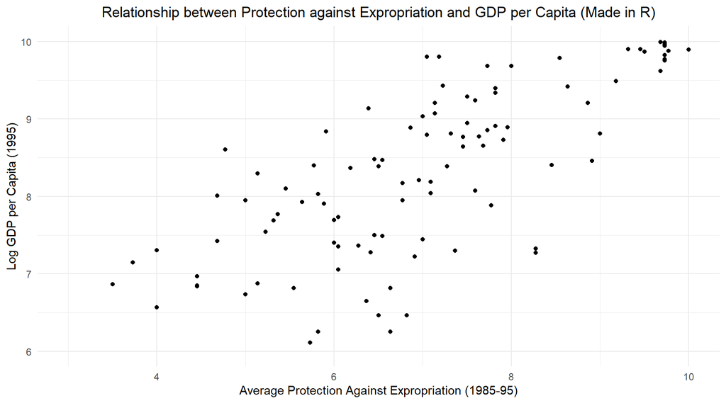

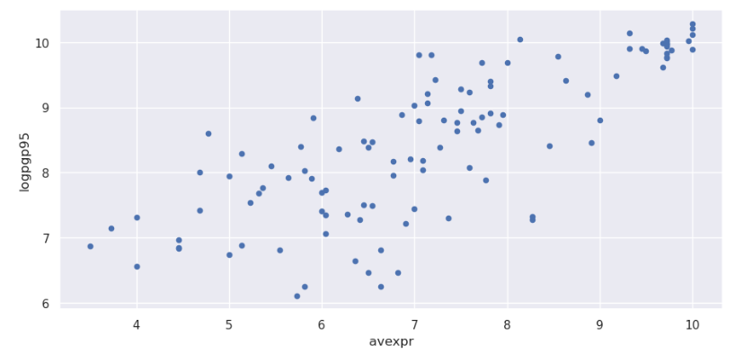

```r
ggplot(df_clean, aes(x = avexpr, y = logpgp95)) +
  geom_point() +
  labs(title = "Relationship between Protection against Expropriation and GDP per Capita (Made in R)",
       x = "Average Protection Against Expropriation (1985-95)",
       y = "Log GDP per Capita (1995)") +
  theme_minimal() +
  theme(plot.title = element_text(hjust = 0.5)) +
  scale_x_continuous(limits = c(3, 10)) +
  scale_y_continuous(limits = c(6, 10))
```

The plots above show the comparison of the scatter plots generated using R and Python.

The adjusted plots ensure that both visualizations are directly comparable, highlighting the strong positive correlation between protection against expropriation and GDP per capita.

Given the plot, We can write our model as:

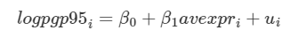

where:

- `β0` is the intercept of the linear trend line on the y-axis,
- `β1` is the slope of the linear trend line, representing the marginal effect of protection against risk on log GDP per capita,
- `u(i)` is a random error term (deviations of observations from the linear trend due to factors not included in the model).

Visually, this linear model involves choosing a straight line that best fits the data, as in the following plots:

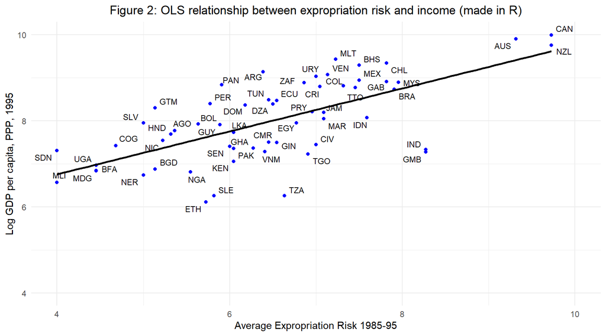

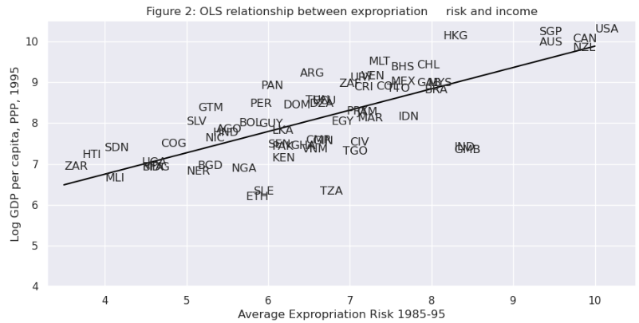

```r
df_subset <- df_clean %>%
  filter(baseco == 1)

ggplot(df_subset, aes(x = avexpr, y = logpgp95)) +
  geom_point(color = "blue") +
  geom_text_repel(aes(label = shortnam), size = 3) +
  geom_smooth(method = "lm", se = FALSE, color = "black") +
  scale_x_continuous(limits = c(3.3, 10.5)) +
  scale_y_continuous(limits = c(4, 10.5)) +
  labs(title = "Figure 2: OLS relationship between expropriation risk and income (made in R)",
       x = "Average Expropriation Risk 1985-95",
       y = "Log GDP per capita, PPP, 1995") +
  theme_minimal() +
  theme(plot.title = element_text(hjust = 0.5)) +
  scale_x_continuous(limits = c(4, 10)) +
  scale_y_continuous(limits = c(4, 10))
```

Moving on into regression part, to estimate the constant term we need to add a column of 1’s to our dataset:

```r
df_clean$const <- 1
```

Now we can construct our model:

```r
reg1 <- lm(logpgp95 ~ avexpr, data = df_clean)
stargazer(reg1, type = "text", title = "OLS Regression Results")
```

```
##
## OLS Regression Results
## ===============================================
##                         Dependent variable:
##                     ---------------------------
##                              logpgp95
## -----------------------------------------------
## avexpr                       0.532***
##                               (0.041)
##
## Constant                     4.626***
##                               (0.301)
##
## -----------------------------------------------
## Observations                    111
## R2                             0.611
## Adjusted R2                    0.608
## Residual Std. Error      0.718 (df = 109)
## F Statistic          171.438*** (df = 1; 109)
## ===============================================
## Note:               *p<0.1; **p<0.05; ***p<0.01
```

The summary of the linear regression model provides detailed information about the estimated relationship between `avexpr` and `logpgp95`. Key metrics include the coefficients, R-squared value, and p-values, which indicate the strength and significance of the relationship.

```r
data <- data.frame(
  Coefficient = c("The intercept", "The slope", "R-squared", "F-statistic"),
  Results_in_R = c("4.626", "0.532", "0.611", "171.438"),
  Results_in_Python = c("4.6261", "0.5319", "0.611", "171.4")
)
kable(data)
```

| Coefficient | Results_in_R | Results_in_Python |
| --- | --- | --- |
| The intercept | 4.626 | 4.6261 |
| The slope | 0.532 | 0.5319 |
| R-squared | 0.611 | 0.611 |
| F-statistic | 171.438 | 171.4 |

Both the intercept (4.626 in R vs. 4.6261 in Python) and the slope (0.532 in R vs. 0.5319 in Python) are nearly identical, indicating that the linear relationships captured by both models are consistent.The positive β1 parameter estimate implies that institutional quality has a positive effect on economic outcomes, as we saw in the figure. Also the p-value of 0.000 for `β1` implies that the effect of institutions on GDP is statistically significant (using p < 0.05 as a rejection rule).

The R-squared value, which indicates the proportion of the variance in the dependent variable that is predictable from the independent variable, is the same (0.611) in both R and Python. The of 0.611 indicates that around 61% of variation in log GDP per capita is explained by protection against expropriation.

The F-statistic values (171.438 in R vs. 171.4 in Python) are also very close, suggesting that the overall significance of the model is consistent between both implementations.

Using our parameter estimates, we can now write our estimated relationship as

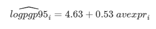

The minor differences in the results are due to rounding differences between the two software environments. Overall, the results are highly consistent, demonstrating that the regression analysis yields similar outcomes regardless of whether R or Python is used.

# 7. Multivariate Regression Model

In this section, we extend the linear regression model to include additional explanatory variables. This multivariate regression model allows us to control for other factors that might influence the relationship between institutional quality and economic outcomes.

So far, we have only accounted for institutions affecting economic performance. Almost certainly, there are numerous other factors affecting GDP that are not included in our model. Leaving out variables that affect `logpgp95` will result in omitted variable bias, yielding biased and inconsistent parameter estimates.

We can extend our bivariate regression model to a multivariate regression model by adding other factors that may affect `logpgp95`. We consider other factors such as:

- The effect of climate on economic outcomes - latitude is used to proxy this.
- Differences that affect both economic performance and institutions, e.g., cultural, historical, etc. - controlled for with the use of continent dummies.

We use a different dataset for this part of the analysis, which includes additional variables:

```r
df2 <- read_dta('https://github.com/QuantEcon/lecture-python/blob/master/source/_static/lecture_specific/ols/maketable2.dta?raw=true')

df2 <- df2 %>%
  mutate(const = 1)
```

Next, we define three sets of explanatory variables to be used in separate regression models:

- **Model 1**: Includes the constant term and `avexpr`.
- **Model 2**: Includes the constant term, `avexpr`, and `lat_abst`.
- **Model 3**: Includes the constant term, `avexpr`, `lat_abst`, `asia`, `africa`, and `other`.

```r
reg1 <- lm(logpgp95 ~ const + avexpr, data = df2)
reg2 <- lm(logpgp95 ~ const + avexpr + lat_abst, data = df2)
reg3 <- lm(logpgp95 ~ const + avexpr + lat_abst + asia + africa + other, data = df2)

stargazer(reg1, reg2, reg3,
          type = "text",
          title = "Table 2 - OLS Regressions (made in R)",
          column.labels = c("Model 1", "Model 2", "Model 3"),
          dep.var.labels = "logpgp95",
          covariate.labels = c("Constant", "Average Expropriation Risk", "Latitude", "Asia", "Africa", "Other"),
          keep.stat = c("n", "rsq"),
          float = TRUE,
          float.env = "table",
          digits = 2)
```

```
##
## Table 2 - OLS Regressions (made in R)
## ========================================================
##                                 Dependent variable:
##                            -----------------------------
##                                      logpgp95
##                             Model 1   Model 2   Model 3
##                               (1)       (2)       (3)
## --------------------------------------------------------
## Constant
##
##
## Average Expropriation Risk  0.53***   0.46***   0.39***
##                             (0.04)    (0.06)    (0.05)
##
## Latitude                               0.87*     0.33
##                                       (0.49)    (0.45)
##
## Asia                                             -0.15
##                                                 (0.15)
##
## Africa                                         -0.92***
##                                                 (0.17)
##
## Other                                            0.30
##                                                 (0.37)
##
## Constant                    4.63***   4.87***   5.85***
##                             (0.30)    (0.33)    (0.34)
##
## --------------------------------------------------------
## Observations                  111       111       111
## R2                           0.61      0.62      0.72
## ========================================================
## Note:                        *p<0.1; **p<0.05; ***p<0.01
```

In **Model 1** the regression includes only the constant term and `avexpr`. The coefficient for `avexpr` is positive and highly significant, suggesting that higher protection against expropriation is associated with higher GDP per capita.

**Model 2** adds `lat_abst` to control for the effect of climate on economic outcomes. The coefficient for `lat_abst` is positive but only marginally significant.

**Model 3** is the most comprehensive model which includes `asia`, `africa`, and `other` dummy variables to control for continent-level differences. The coefficient for `africa` is negative and highly significant, indicating that, holding other factors constant, African countries have lower GDP per capita. The coefficient for `avexpr` remains positive and significant, though its magnitude decreases slightly compared to the previous models.

```r
multivariate_data <- data.frame(
  Coefficient = c("The intercept", "Average Expropriation Risk", "Latitude", "Asia", "Africa", "Other", "R-squared"),
  Results_in_R_Model1 = c("4.63", "0.53", "", "", "", "", "0.61"),
  Results_in_Python_Model1 = c("4.63", "0.53", "", "", "", "", "0.61"),
  Results_in_R_Model3 = c("4.87", "0.46", "0.87", "", "", "", "0.62"),
  Results_in_Python_Model3 = c("4.87", "0.46", "0.87", "", "", "", "0.62"),
  Results_in_R_Model4 = c("5.85", "0.39", "0.33", "-0.15", "-0.92", "0.30", "0.72"),
  Results_in_Python_Model4 = c("5.85", "0.39", "0.33", "-0.15", "-0.92", "0.30", "0.72")
)


kable(multivariate_data, col.names = c("Coefficient", "Model 1 in R", "Model 1 in Python", "Model 3 in R", "Model 3 in Python", "Model 4 in R", "Model 4 in Python"), align = 'c')
```

[output not shown]

The table above compares the results from the multivariate regression models conducted in R and Python for three different models.

The results are remarkably consistent between R and Python across all models. The coefficients and R-squared values are identical, demonstrating that the regression analysis yields consistent outcomes regardless of the software used. The inclusion of additional variables (latitude and continent dummies) provides a more nuanced understanding of the factors influencing economic outcomes. It shows how the impact of institutional quality (avexpr) changes when accounting for other relevant factors.

The multivariate regression models confirm the positive relationship between institutional quality and economic outcomes, as measured by GDP per capita. The results are consistent across both R and Python, providing robust evidence that better institutional quality is associated with higher economic performance. The inclusion of additional variables such as latitude and continent dummies further refines the analysis, highlighting the importance of considering multiple factors in understanding economic outcomes.

# 8. Endogeneity

Dr. Acemoglu identified a significant issue with Ordinary Least Squares (OLS) regression models: endogeneity, which leads to biased and inconsistent estimates. Specifically, there is a two-way relationship between institutions and economic outcomes:

- Wealthier nations tend to develop better institutions.
- Factors affecting income might also influence institutional variations.
- Institutional indices might be biased, as analysts could link higher incomes with better institutions.

To tackle endogeneity, we used a two-stage least squares (2SLS) regression. This method replaces the endogenous variable avexpr(i) with an instrumental variable that:

- Correlates with `avexpr(i)`.
- Is not correlated with the error term, avoiding direct effects on the dependent variable and thus preventing correlation with `u(i)`.

These new regressors, known as instruments, help eliminate endogeneity in assessing institutional differences. We used settler mortality rates as an instrument for institutional differences. Thee hypothesis suggests that higher mortality rates among colonizers led to the establishment of more extractive institutions, with less protection against expropriation, which persist today. A scatterplot supports this hypothesis, showing a negative correlation between protection against expropriation and settler mortality rates, meeting the criteria for a valid instrument.

This analysis replicates their methodology, applying 2SLS regression to address endogeneity and evaluate the impact of institutional differences on economic outcomes.

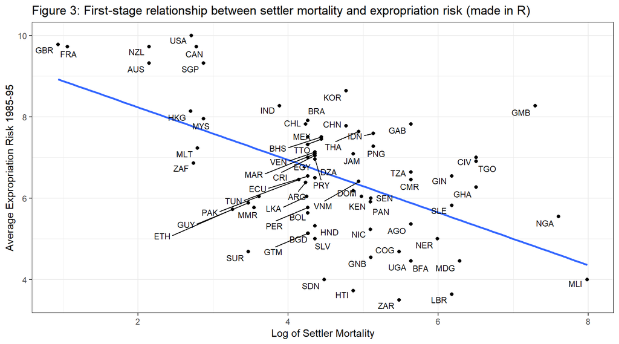

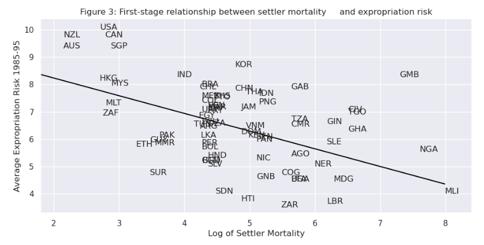

```r
df1_subset2 <- df[complete.cases(df[c("logem4", "avexpr")]) , ]
X <- df1_subset2$logem4
y <- df1_subset2$avexpr
labels <- df1_subset2$shortnam

ggplot(df1_subset2, aes(x = logem4, y = avexpr)) +
  geom_point() +
  geom_smooth(method = "lm", se = FALSE) +
  geom_text_repel(aes(label = labels), hjust = 0, vjust = 0, , size = 3) +
  labs(title = "Figure 3: First-stage relationship between settler mortality and expropriation risk (made in R)",
       x = "Log of Settler Mortality",
       y = "Average Expropriation Risk 1985-95") +
  theme_bw()
```

If settler mortality rates from the 17th to 19th centuries directly affect current GDP, our instrument might not be valid. However there is an argue against this, noting that settler deaths primarily resulted from malaria and yellow fever, with limited impact on local populations. They also observe that disease burdens in regions like Africa or India were not unusually high before colonization, suggesting our instrument remains valid. Therefore, we proceed with 2SLS regression to obtain reliable parameter estimates.

Our findings support those of the original paper, confirming the validity of settler mortality rates as an instrument to address endogeneity concerns.

## 8.1 First stage

In our research, the first stage entails regressing the endogenous variable `avexpr(i)`, on the instrument.

The instrument comprises all exogenous variables in our model, not just the variable being replaced. Taking model 1 as an instance, our instrument consists of a constant and the logarithm of settler mortality rates `logem4(i)`.

Hence, we will estimate the first-stage regression as:

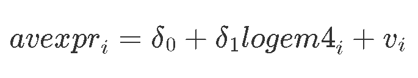

For this analysis, we utilize a different dataset stored in “maketable4.dta”. We exclusively employ complete data, identified by `baseco=1`, for the estimation process.

```r
df4 <- read_dta('https://github.com/QuantEcon/lecture-python/blob/master/source/_static/lecture_specific/ols/maketable4.dta?raw=true')

df4 <- df4 %>%
  filter(baseco == 1)

df4$const <- 1

model_fs <- lm(avexpr ~ const + logem4, data = df4, na.action = "drop")

stargazer(model_fs, type = "text", title = "First-Stage Regression Results (2SLS)",
          covariate.labels = c("Constant", "Log of European Settler Mortality"),
          dep.var.labels = "Average Expropriation Risk",
          digits = 2)
```

```
##
## First-Stage Regression Results (2SLS)
## =============================================================
##                                       Dependent variable:
##                                   ---------------------------
##                                   Average Expropriation Risk
## -------------------------------------------------------------
## Constant
##
##
## Log of European Settler Mortality          -0.61***
##                                             (0.13)
##
## Constant                                    9.34***
##                                             (0.61)
##
## -------------------------------------------------------------
## Observations                                  64
## R2                                           0.27
## Adjusted R2                                  0.26
## Residual Std. Error                     1.26 (df = 62)
## F Statistic                          22.95*** (df = 1; 62)
## =============================================================
## Note:                             *p<0.1; **p<0.05; ***p<0.01
```

```r
data <- data.frame(
  Coefficient = c("The intercept", "logem4(i)", "R-squared", "F-statistic"),
  Results_in_R = c("9.34", "-0.61", "0.27", "22.95"),
  Results_in_Python = c("9.3414", "-0.6068", "0.270", "22.95")
)
kable(data)
```

| Coefficient | Results_in_R | Results_in_Python |
| --- | --- | --- |
| The intercept | 9.34 | 9.3414 |
| logem4(i) | -0.61 | -0.6068 |
| R-squared | 0.27 | 0.270 |
| F-statistic | 22.95 | 22.95 |

## 8.2 Second stage

To proceed, we must obtain the predicted values of `avexpr(i)`. These predicted values are then substituted for the endogenous variable `avexpr(i)` in the original linear model.

Consequently, our second stage regression takes the following form:

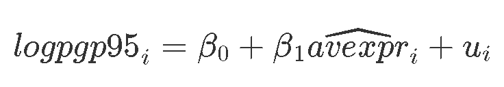

```r
df4$predicted_avexpr <- predict(model_fs, newdata = df4)

model_ss <- lm(logpgp95 ~ const + predicted_avexpr, data = df4)

stargazer(model_ss, type = "text",
          title = "Second-Stage Regression Results (2SLS)",
          covariate.labels = c("Constant", "Predicted Average Expropriation Risk"),
          dep.var.labels = "Log GDP per Capita",
          digits = 2)
```

```
##
## Second-Stage Regression Results (2SLS)
## ================================================================
##                                          Dependent variable:
##                                      ---------------------------
##                                          Log GDP per Capita
## ----------------------------------------------------------------
## Constant
##
##
## Predicted Average Expropriation Risk           0.94***
##                                                (0.13)
##
## Constant                                       1.91**
##                                                (0.82)
##
## ----------------------------------------------------------------
## Observations                                     64
## R2                                              0.48
## Adjusted R2                                     0.47
## Residual Std. Error                        0.76 (df = 62)
## F Statistic                             56.60*** (df = 1; 62)
## ================================================================
## Note:                                *p<0.1; **p<0.05; ***p<0.01
```

```r
data <- data.frame(
  Coefficient = c("The intercept", "avexpr(i)", "R-squared", "F-statistic"),
  Results_in_R = c("1.91", "0.94", "0.48", "56.60"),
  Results_in_Python = c("1.9097", "0.9443", "0.477", "56.60")
)
kable(data)
```

| Coefficient | Results_in_R | Results_in_Python |
| --- | --- | --- |
| The intercept | 1.91 | 1.9097 |
| avexpr(i) | 0.94 | 0.9443 |
| R-squared | 0.48 | 0.477 |
| F-statistic | 56.60 | 56.60 |

The second-stage regression outcomes provide an unbiased and consistent estimate of the influence of institutions on economic outcomes, mirroring those of the original paper. Notably, the results suggest a more pronounced positive relationship than what the OLS results had indicated.

Although our parameter estimates are accurate, the standard errors are not. Therefore, conducting 2SLS “manually” (in stages with OLS) is discouraged.

Instead, we will appropriately estimate a 2SLS regression in one step using the ivreg function from the AER package.

```r
model_ss <- ivreg(logpgp95 ~ avexpr + const | logem4 + const, data = df4)

stargazer(model_ss, type = "text",
          title = "Second-Stage Regression Results (2SLS)",
          covariate.labels = c("Average Expropriation Risk", "Constant"),
          dep.var.labels = "Log GDP per Capita",
          digits = 2)
```

```
##
## Second-Stage Regression Results (2SLS)
## ======================================================
##                                Dependent variable:
##                            ---------------------------
##                                Log GDP per Capita
## ------------------------------------------------------
## Average Expropriation Risk           0.94***
##                                      (0.16)
##
## Constant
##
##
## Constant                              1.91*
##                                      (1.03)
##
## ------------------------------------------------------
## Observations                           64
## R2                                    0.19
## Adjusted R2                           0.17
## Residual Std. Error              0.95 (df = 62)
## ======================================================
## Note:                      *p<0.1; **p<0.05; ***p<0.01
```

```r
data <- data.frame(
  Coefficient = c("The intercept", "avexpr(i)", "R-squared"),
  Results_in_R = c("1.91", "0.94", "0.19"),
  Results_in_Python = c("1.9097", "0.9443", "0.1870")
)
kable(data)
```

| Coefficient | Results_in_R | Results_in_Python |
| --- | --- | --- |
| The intercept | 1.91 | 1.9097 |
| avexpr(i) | 0.94 | 0.9443 |
| R-squared | 0.19 | 0.1870 |

With our consistent and unbiased estimates, we can deduce from the model that institutional disparities, originating from colonial-era institutions, contribute to variations in income levels among countries today.

According to Dr. Acemoglu, a marginal effect of 0.94 suggests that the disparity in the index between Chile and Nigeria (i.e., institutional quality) could lead to a sevenfold difference in income, underscoring the pivotal role of institutions in economic development.

# 9. Summary

In our research we applied basic Ordinary Least Squares (OLS) and Two-Stage Least Squares (2SLS) regression techniques. Our findings reveal that while OLS regression may suffer from endogeneity issues, 2SLS regression offers a solution by addressing this concern. Through 2SLS regression, we obtained consistent and unbiased estimates, allowing us to infer that institutional differences established during colonization significantly contribute to the disparities in income levels among countries today. Our research further illustrate the profound impact of institutions on economic development, emphasizing their pivotal role in shaping the economic landscape. Importantly, our results fully reproduce the findings of Dr. Acemoglu, validating the robustness of our analysis.